# Exploratory Data Analysis Course Notes

## Principle of Analytic Graphics

- **Principle 1: Show Comparisons**
  - always comparative (compared to what)
  - randomized trial - compare control group to test group
  - evidence for a hypothesis is always relative to another competing hypothesis
  - *example*: Two graphs showing the difference in Pokemon happiness after being taken on walks (graph 1: test) and not being taken on walks (graph 2: control)
- **Principle 2: Show explanation / causality**
  - what is the reason for the results shown by the test group?
  - form hypothesis to evidence showing a relationship (why something happened)
  - *example:* Another graph showing the level of Attention From Trainer for Pokemon who go on waks and those who do not. The difference in Pokemon Happiness within the Test Group could be explained by the increase in attention from the owner when Pokemon are taken on walks
- **Principle 3: Show multivariate data**
- more than 2 variables because the real world is multivariate
  - show as much data on a plot as you can
  - *example*

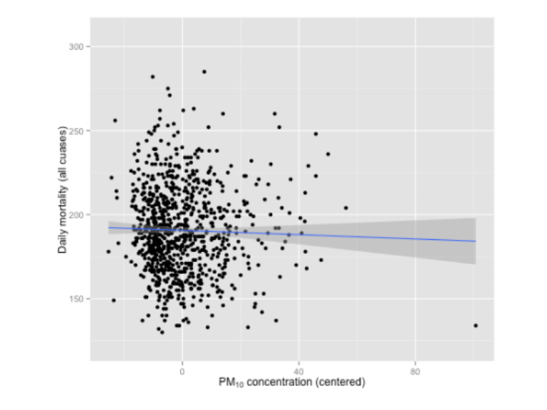

- slightly negative relationship between pollution and mortality
  - when split up by season, the relationships are all positive $\rightarrow$ season = confounding variable

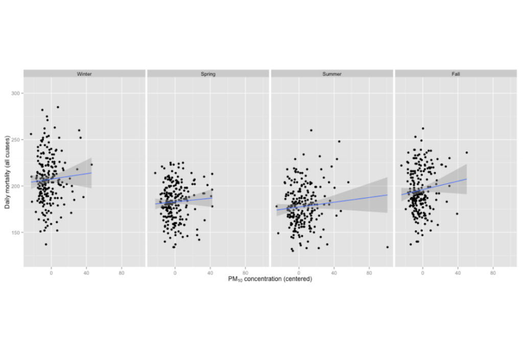

- **Principle 4: Integration of evidence**
  - use as many modes of evidence/displaying evidence as possible (modes of data presentation)
  - integrate words/numbers/images/diagrams (information rich)
  - analysis should drive the tool
- **Principle 5: Describe/document evidence with appropriate labels/scales/sources**
  - add credibility to that data graphic
- **Principle 6: Content is the most important**
  - analytical presentations ultimately stand/fall depending on quality/relevance/integrity of content

## Exploratory Graphs

- **Purpose**: What does my data look like? Understand data properties, find pattern in data, suggest modeling strategies (do we use linear or non-linear?), debug.
- **Characteristics**: made quickly, large number produced, gain personal understanding, appearances and presentation are aren’t as important

### One Dimension Summary of Data

- `summary(data)` = returns min, 1st quartile, median, mean, 3rd quartile, max
- `boxplot(data$v1, col = “blue”)` = produces a box with middles 50% highlighted in the specified colour. Graphical output of `summary()`.
- `histogram(data$v1, col = "green")` = produces a histogram with specified breaks and colour
  - `breaks = 100` = number of bars. The higher the number is the smaller/narrower the histogram columns are. Too big = noisey / rough, too small = can’t see shape of distribution
- `rug(data$v1)` = density plot, adds strip under histrogram indicating location of each data point
- `barplot(table(data), col = "wheat", main = "Title")` = produces a bar graph, usually for categorical data
- **overlaying features**
  - `abline(h/v = 12)` = overlays a horizontal (boxplot) or vertical (histogram) line at specificed location.
  - `col = “red”` = specifies color
  - `lwd = 4` = line width
  - `lty = 2` = line type
  - Horziontal line useful over `boxplot` to see how much data falls at specified value.
  - *example:* How many islands speak 12 languages?
    - `boxplot(data)`;`abline(h = 12)`. If line is above box, then less than 75% (3rd quartile) of islands speak 12 languages.
  - Vertical line useful over `histogram`
    - `abline(v = meadian(data), col = blue, lwd = 4)` = displays median line. *note* boxplot contains median line as feature, histogram does not

### Two Dimensional Summaries

- multiple/overlayed 1-D plots (Lattice/ggplot2 )
- **box plots**: `boxplot(pm25 ~ region, data = pollution, col = “red”)`
- air pollution in east is higher than west. Lower in west but more spread out, with high extreme values

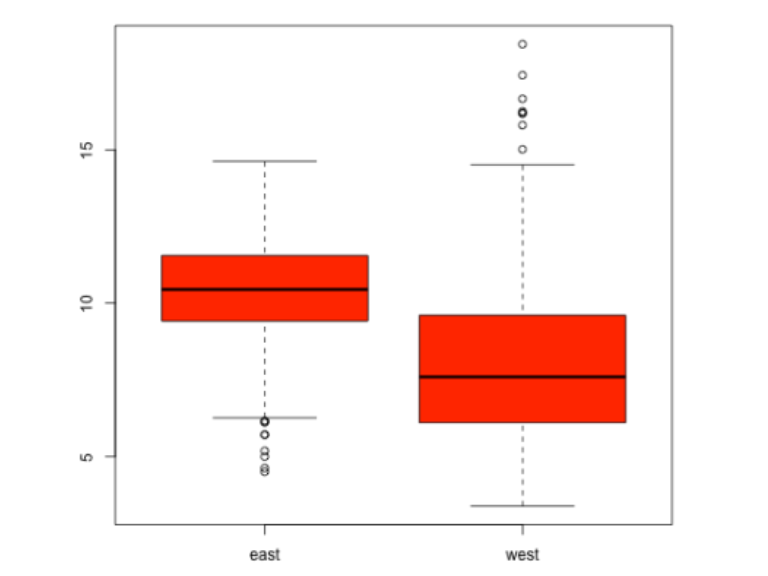

- **histogram**:
  - `par(mfrow = c(2, 1), mar = c(4, 4, 2, 1))` = set margin
  - `hist(subset(pollution, region == "east")$pm25, col = "green")` = first histogram
  - `hist(subset(pollution, region == "west")$pm25, col = "green")` = second histogram
- air pollution in east is higher than west, but no extreme values. Lower in west but more spread out, with high extreme values

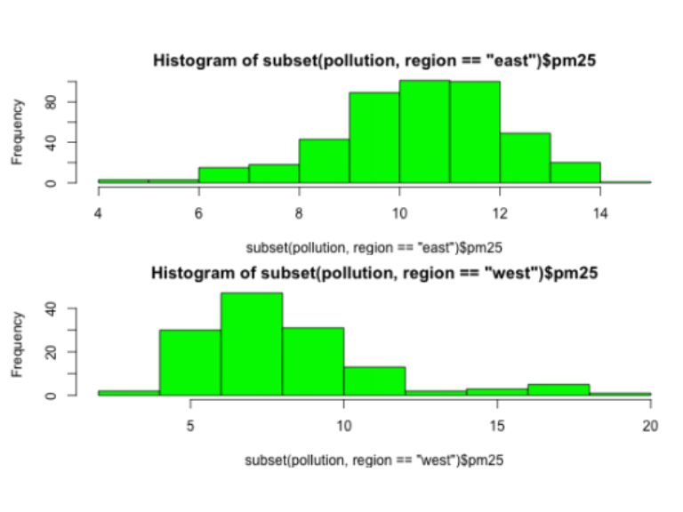

[figure not shown]

- **mutiple scatterplot**
- another way of looking at three variables instead of using colour
- `par(mfrow = c(1, 2), mar = c(5, 4, 2, 1))` = sets margins
  - `with(subset(pollution, region == "west"), plot(latitude, pm25, main = "West"))` = left scatterplot
  - `with(subset(pollution, region == "east"), plot(latitude, pm25, main = "East"))` = right scatterplot

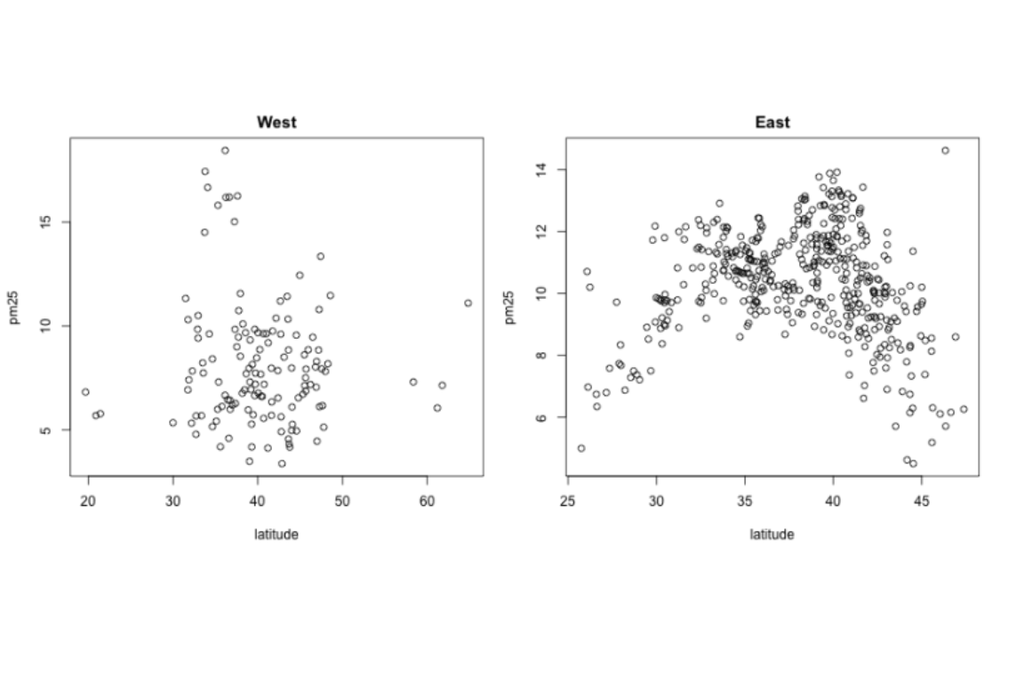

* both scatterplots (single & multiple) show that for pollution is higher in mid-latitudes than low / high latitudes for both eastern and western regions.

- **scatterplot**
- `with(pollution, plot(latitude, pm25, col = region))`
  - `abline(h = 12, lwd = 2, lty = 2)` = plots horizontal dotted line showing the standard air quality level
  - `plot(jitter(child, 4)~parent, galton)` = spreads out data points at the same position to simulate measurement error/make high frequency more visibble
- **summary**
- quick and dirty
- Explore basic questions and hypotheses (perhaps rule them out)

### Process of Making a Plot/Considerations

- where will plot be made? screen or file?
- how will plot be used? viewing on screen/web browser/print/presentation?
- large amount of data vs few points?
- need to be able to dynamically resize?
- **plotting system**: base, lattice, ggplot2?